# Consumer Loan Default Prediction

## Problem Statement

Banks play a crucial role in market economies. They decide who can get finance and on what terms and can make or break investment decisions. For markets and society to function, individuals and companies need access to credit.

However, giving loan can be a risky business. What if the person or companies, banks have granted loan to are not able to pay it back. It’s not easy to determine the future. However, we can predict the probability of default by a customer by using, Credit Scoring algorithms.

Banks use Credit scores to determine the credit worthiness of the candidate and based on their credit scores they can determine the probabilities of returns.

In this study our goal is to build a model that borrowers can use to help make the best financial decisions. The data is raw, you may have to spend considerable amount of time for validating and cleaning the data.

### Business Model

Banks make profits by interest on credit or loans they have provided to their customers for their needs. Banks have to be careful about whom to grant a loan, as the margin on the interst is quite low but the loss associated with defaulting the loan can be tough to recover. Reducing the probability of a loan default is a priority for a bank. To reduce such cases, banks check credit worthiness of the borrower before giving out any loan. Banks build a model to decide weather a cuatomer is a good candidate for loan or not using information provided by customer an historical loan data which helps banks to find the probability of any future default. Using the data given to us about the borrowers and we will try to build a model which can predict whether a borrower will be able to pay loan or default the loan.

## Data Exploration

Once we have the dataset and metadata, understanding metadata thoroughly is a crucial step. Exploration helps us understand all the variables throughly which is necessary to understand relation between input and predictive variables. Exploration also provides a vague understanding of what’s going on with the dataset.

First step is to import the data set to R. Formats like .csv,.xlsx etc are the common data formats used by data scientists or analysts. Use suitable function to import it into R. In our case data set is in csv format. So we use the function ‘read.csv()’ to import the data set.

```r
train_data<-read.csv("D:\\Statinfer\\Datasets\\Give me some Credit\\cs-training.csv")
```

We are assigning the data to the variable ‘train_data’

See the dimension of the data.

```r
dim(train_data)
```

```
## [1] 150000     12
```

we have 12 variables, and 150000 observations.

Get the variable names.

```r
names(train_data)
```

```
##  [1] "Sr_No"
##  [2] "SeriousDlqin2yrs"
##  [3] "RevolvingUtilizationOfUnsecuredLines"
##  [4] "age"
##  [5] "NumberOfTime30.59DaysPastDueNotWorse"
##  [6] "DebtRatio"
##  [7] "MonthlyIncome"
##  [8] "NumberOfOpenCreditLinesAndLoans"
##  [9] "NumberOfTimes90DaysLate"
## [10] "NumberRealEstateLoansOrLines"
## [11] "NumberOfTime60.89DaysPastDueNotWorse"
## [12] "NumberOfDependents"
```

The lable if the column can be diffrenet than the name of the variable, check these names with the names in given metadata file. In the dataset we are using, names are same in both. There is an extra variable ‘Sr_No’ which is the serial number.

see the structure of the data

```r
str(train_data)
```

```
## 'data.frame':    150000 obs. of  12 variables:
##  $ Sr_No                               : int  1 2 3 4 5 6 7 8 9 10 ...
##  $ SeriousDlqin2yrs                    : int  1 0 0 0 0 0 0 0 0 0 ...
##  $ RevolvingUtilizationOfUnsecuredLines: num  0.766 0.957 0.658 0.234 0.907 ...
##  $ age                                 : int  45 40 38 30 49 74 57 39 27 57 ...
##  $ NumberOfTime30.59DaysPastDueNotWorse: int  2 0 1 0 1 0 0 0 0 0 ...
##  $ DebtRatio                           : num  0.803 0.1219 0.0851 0.036 0.0249 ...
##  $ MonthlyIncome                       : int  9120 2600 3042 3300 63588 3500 NA 3500 NA 23684 ...
##  $ NumberOfOpenCreditLinesAndLoans     : int  13 4 2 5 7 3 8 8 2 9 ...
##  $ NumberOfTimes90DaysLate             : int  0 0 1 0 0 0 0 0 0 0 ...
##  $ NumberRealEstateLoansOrLines        : int  6 0 0 0 1 1 3 0 0 4 ...
##  $ NumberOfTime60.89DaysPastDueNotWorse: int  0 0 0 0 0 0 0 0 0 0 ...
##  $ NumberOfDependents                  : int  2 1 0 0 0 1 0 0 NA 2 ...
```

In our data some variables are integers and some are numeric. Sometimes, categorical variables are given a integer value for each category.

To see the first five and last five rows of the data to get better understanding of variables.

```r
head(train_data)
```

```
##   Sr_No SeriousDlqin2yrs RevolvingUtilizationOfUnsecuredLines age
## 1     1                1                            0.7661266  45
## 2     2                0                            0.9571510  40
## 3     3                0                            0.6581801  38
## 4     4                0                            0.2338098  30
## 5     5                0                            0.9072394  49
## 6     6                0                            0.2131787  74
##   NumberOfTime30.59DaysPastDueNotWorse  DebtRatio MonthlyIncome
## 1                                    2 0.80298213          9120
## 2                                    0 0.12187620          2600
## 3                                    1 0.08511338          3042
## 4                                    0 0.03604968          3300
## 5                                    1 0.02492570         63588
## 6                                    0 0.37560697          3500
##   NumberOfOpenCreditLinesAndLoans NumberOfTimes90DaysLate
```

[output cut: 20 more lines]

```r
tail(train_data)
```

```
##         Sr_No SeriousDlqin2yrs RevolvingUtilizationOfUnsecuredLines age
## 149995 149995                0                           0.38574226  50
## 149996 149996                0                           0.04067386  74
## 149997 149997                0                           0.29974515  44
## 149998 149998                0                           0.24604392  58
## 149999 149999                0                           0.00000000  30
## 150000 150000                0                           0.85028295  64
##        NumberOfTime30.59DaysPastDueNotWorse    DebtRatio MonthlyIncome
## 149995                                    0    0.4042929          3400
## 149996                                    0    0.2251309          2100
## 149997                                    0    0.7165622          5584
## 149998                                    0 3870.0000000            NA
## 149999                                    0    0.0000000          5716
## 150000                                    0    0.2499081          8158
##        NumberOfOpenCreditLinesAndLoans NumberOfTimes90DaysLate
```

[output cut: 20 more lines]

We can see the summary of whole data data using summary() function.

```r
summary(train_data)
```

```
##      Sr_No        SeriousDlqin2yrs  RevolvingUtilizationOfUnsecuredLines
##  Min.   :     1   Min.   :0.00000   Min.   :    0.00
##  1st Qu.: 37501   1st Qu.:0.00000   1st Qu.:    0.03
##  Median : 75001   Median :0.00000   Median :    0.15
##  Mean   : 75001   Mean   :0.06684   Mean   :    6.05
##  3rd Qu.:112500   3rd Qu.:0.00000   3rd Qu.:    0.56
##  Max.   :150000   Max.   :1.00000   Max.   :50708.00
##
##       age        NumberOfTime30.59DaysPastDueNotWorse   DebtRatio
##  Min.   :  0.0   Min.   : 0.000                       Min.   :     0.0
##  1st Qu.: 41.0   1st Qu.: 0.000                       1st Qu.:     0.2
##  Median : 52.0   Median : 0.000                       Median :     0.4
##  Mean   : 52.3   Mean   : 0.421                       Mean   :   353.0
##  3rd Qu.: 63.0   3rd Qu.: 0.000                       3rd Qu.:     0.9
##  Max.   :109.0   Max.   :98.000                       Max.   :329664.0
##
##  MonthlyIncome     NumberOfOpenCreditLinesAndLoans NumberOfTimes90DaysLate
##  Min.   :      0   Min.   : 0.000                  Min.   : 0.000
##  1st Qu.:   3400   1st Qu.: 5.000                  1st Qu.: 0.000
##  Median :   5400   Median : 8.000                  Median : 0.000
##  Mean   :   6670   Mean   : 8.453                  Mean   : 0.266
##  3rd Qu.:   8249   3rd Qu.:11.000                  3rd Qu.: 0.000
##  Max.   :3008750   Max.   :58.000                  Max.   :98.000
##  NA's   :29731
##  NumberRealEstateLoansOrLines NumberOfTime60.89DaysPastDueNotWorse
##  Min.   : 0.000               Min.   : 0.0000
##  1st Qu.: 0.000               1st Qu.: 0.0000
##  Median : 1.000               Median : 0.0000
##  Mean   : 1.018               Mean   : 0.2404
##  3rd Qu.: 2.000               3rd Qu.: 0.0000
##  Max.   :54.000               Max.   :98.0000
##
##  NumberOfDependents
##  Min.   : 0.000
##  1st Qu.: 0.000
##  Median : 0.000
##  Mean   : 0.757
##  3rd Qu.: 1.000
##  Max.   :20.000
##  NA's   :3924
```

Summary will show the minimum,maximum,mean,median,1<sup>st</sup> quartile,3<sup>rd</sup> quartile of all the variables in the data set. It also shows whether any variable has NA(missing) values. In our data, variables ‘MonthlyIncome’ and ‘NumberOfDependents’ have NA values. Summary gives mean of variables after excluding NA values.

Missing values aren’t always represented by ‘NA’. We can also find ‘?’,‘-’,‘.’ etc as denotation for missing values. Summary and frequency table of the variable are best ways to find the presence of missing values. Frequency table allows us to find any notation used for missing value. Once we know the representation of the missing values, we can find number of missing values in each variable and move toward missing value treatment.

In our dataset missing values are represented by ‘NA’. Lets find out number of missing values in each variable.

```r
missing_values=0
for(i in 1:ncol(train_data)){
  missing_values[i]=sum(is.na(train_data[,i]))
  }

#is.na will check whether a value is 'NA' or not,and gives output TRUE(1),False(0) respectively. sum() will give sum of all the 1's.
```

We got the number of missing values of all the variables in a vector.

```r
missing_values
```

```
##  [1]     0     0     0     0     0     0 29731     0     0     0     0
## [12]  3924
```

Next, we will move to Univariate Analysis to understand more about each variable.

### Univariate Analysis

In univariate analysis, we validate one variable at a time. This allow us know what each variable signifies and how it is related to predicting variable. Method to perform Univariate analysis depends on weather the variable is continuous or categorical. -1. **Continuous** : Central tendency(mean, median, mode etc.)and spread of the variable or dispersion(range, quartile, variance, skewness-kurtosis etc.) is the basic way to deal with continuous variables. These can be measured using various statistical metrics. Boxplot can be used for visulisation. -2. **Categorical** : Frequency tables are used for analysing categorical variables. Count of each variable and/or percentage count helps us understand categorical data. Bar charts can be used for visulisation.

This also helps us identifying any missing values, outliers etc. Once we sanitize the variable data it can be used for final model building.

> Sr_No

It is the first variable in the data. It is serial number. We can get its summary

```r
summary(train_data$Sr_No)
```

```
##    Min. 1st Qu.  Median    Mean 3rd Qu.    Max.
##       1   37500   75000   75000  112500  150000
```

> SeriousDlqin2yrs

Variable ‘SeriousDlqin2yrs’ tells whether a person experienced 90 days past due delinquency or worse. This is the target variable which we have to predict. Being a binary variable, value is either 1(yes) or 0(no).

```r
summary(train_data$SeriousDlqin2yrs)
```

```
##    Min. 1st Qu.  Median    Mean 3rd Qu.    Max.
## 0.00000 0.00000 0.00000 0.06684 0.00000 1.00000
```

Since it is a yes/no type variable we will get frequency table for better understanding of the variable.

```r
count<-table(train_data$SeriousDlqin2yrs)
count
```

```
##
##      0      1
## 139974  10026
```

Out of 150000 only 10026 are bad accounts, which shows we might be dealing with ‘imbalanced data’. We will discuss more about imbalanced data in model building.

We draw bar plot of the variable for better visualisation.

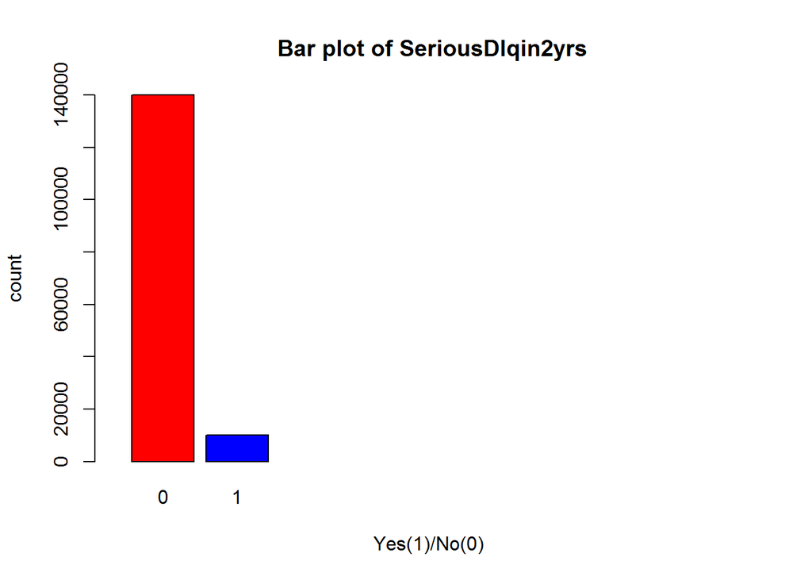

```r
library(ggplot2)
barplot(count,width=0.2,col = c("red","blue"),ylim = c(0, 140000),xlim=c(0,2),main=" Bar plot of SeriousDlqin2yrs",xlab="Yes(1)/No(0)",ylab="count")
```

> RevolvingUtilizationOfUnsecuredLines

This variable represents total balance on credit cards and personal lines of credit, except, real estate and no-installment debt like car loans divided by the sum of credit limits. As this variable is a ratio, the value must be between 0 and 1.

```r
summary(train_data$RevolvingUtilizationOfUnsecuredLines)
```

```
##     Min.  1st Qu.   Median     Mean  3rd Qu.     Max.
##     0.00     0.03     0.15     6.05     0.56 50710.00
```

The mean is 6.05, which is greater than 1.This variable seem to have some faulty values. The maximum value is 50710 which is way too high.

Lets look at percentiles to know from where it is exceeding 1.

```r
quantile(train_data$RevolvingUtilizationOfUnsecuredLines,c(0.9,0.91,0.95,0.96,0.97,0.975,0.98,0.99,1))
```

```
##          90%          91%          95%          96%          97%
## 9.812777e-01 9.999999e-01 9.999999e-01 9.999999e-01 9.999999e-01
##        97.5%          98%          99%         100%
## 9.999999e-01 1.006199e+00 1.092956e+00 5.070800e+04
```

Things does’t seem that clear, let’s try a visual approach. Drawing a boxplot can give us more insights on this variable.

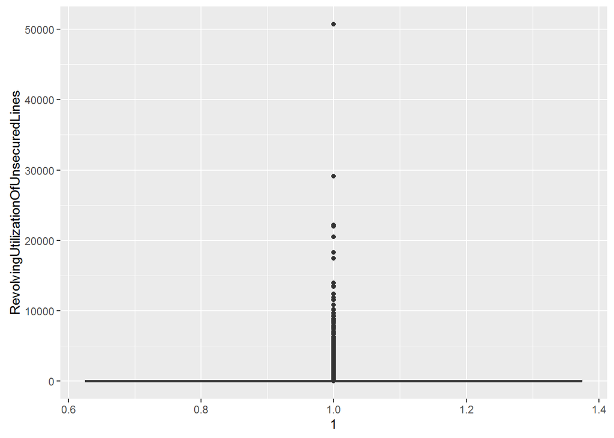

```r
ggplot(train_data, aes(y=RevolvingUtilizationOfUnsecuredLines, x = 1)) + geom_boxplot()
```

We can see that there are outliers present in the variable.

> age

It specifies age of the barrower in years. Its’ an integer. lets see the summary of age

```r
summary(train_data$age)
```

```
##    Min. 1st Qu.  Median    Mean 3rd Qu.    Max.
##     0.0    41.0    52.0    52.3    63.0   109.0
```

Minimum age is 0, which is not practical. Maximum age is 109 which is ok. Mean and median are very close which indicates outliers may not be present.

Lets see the percentile distribution.

```r
quantile(train_data$age,c(0,0.01,0.03,0.05,0.07,0.09,0.1,0.2,0.3,0.4,0.5,0.6,0.7,0.8,0.9,1))
```

```
##   0%   1%   3%   5%   7%   9%  10%  20%  30%  40%  50%  60%  70%  80%  90%
##    0   24   27   29   30   32   33   39   44   48   52   56   61   65   72
## 100%
##  109
```

Check whether any barrower age is less than 20 as banks avoid giving credit to teenagers.

```r
sum(train_data$age<20)
```

```
## [1] 1
```

There is only one borrower whose age is less than 20. That barrower is of minimum age 0. This is not possible as banks can not give credit to unborn.

Plot the boxplot of the variable

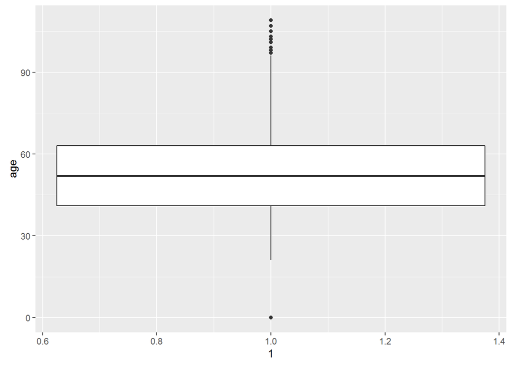

```r
ggplot(train_data, aes(y=age, x = 1)) + geom_boxplot()
```

We can notice the outlier at the bottom of the boxplot.

> NumberOfTime30.59DaysPastDueNotWorse

This variable shows number of times a borrower has been between 30-59 days past due, but no worse in the last 2 years.

```r
str(train_data$NumberOfTime30.59DaysPastDueNotWorse)
```

```
##  int [1:150000] 2 0 1 0 1 0 0 0 0 0 ...
```

```r
summary(train_data$NumberOfTime30.59DaysPastDueNotWorse)
```

```
##    Min. 1st Qu.  Median    Mean 3rd Qu.    Max.
##   0.000   0.000   0.000   0.421   0.000  98.000
```

```r
sd(train_data$NumberOfTime30.59DaysPastDueNotWorse)
```

```
## [1] 4.192781
```

It is an integer variable. Minimum value is zero, median is also zero. Mean is 0.421 , SD is 4.192 and maximum value is 98. These give indication of presence of outliers.

Check the percentile distribution to know the presence of outliers.

```r
quantile(train_data$NumberOfTime30.59DaysPastDueNotWorse,c(0,0.01,0.03,0.05,0.07,0.09,0.1,0.2,0.3,0.4,0.5,0.6,0.7,0.8,0.85,0.9,0.95,1))
```

```
##   0%   1%   3%   5%   7%   9%  10%  20%  30%  40%  50%  60%  70%  80%  85%
##    0    0    0    0    0    0    0    0    0    0    0    0    0    0    1
##  90%  95% 100%
##    1    2   98
```

100 percentile is 98, which is an outlier.

This variable range is from 0 to 98. It takes only integers values. Lets see it’s frequency distribution.

```r
freq_table<-table(train_data$NumberOfTime30.59DaysPastDueNotWorse)
freq_table
```

```
##
##      0      1      2      3      4      5      6      7      8      9
## 126018  16033   4598   1754    747    342    140     54     25     12
##     10     11     12     13     96     98
##      4      1      2      1      5    264
```

This variables has values from 0 to 13 and 96,98. Last two must be the outliers.

Let’s plot boxplot and barplots to visualize the data.

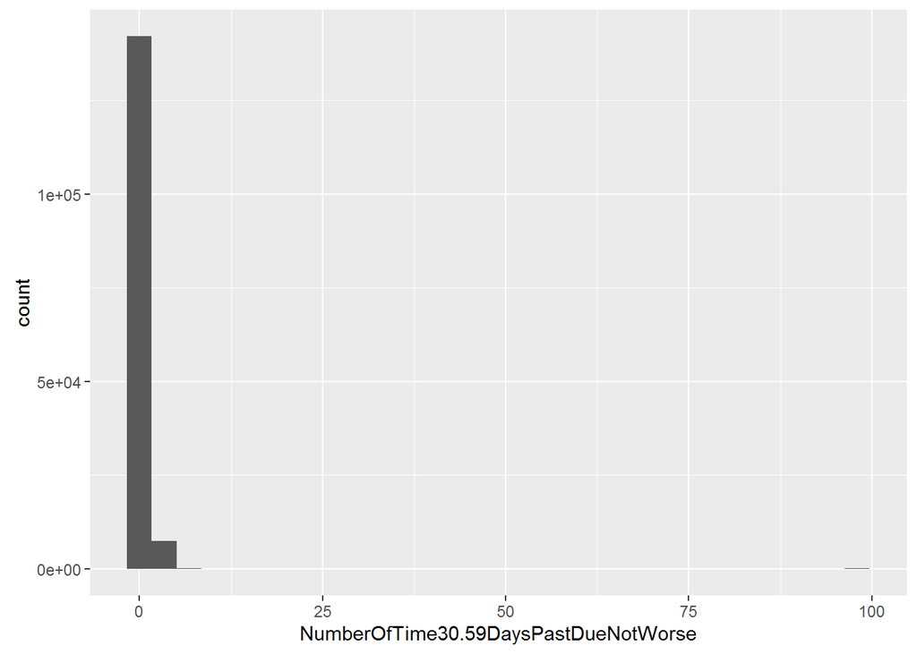

```r
qplot(data = train_data, x = NumberOfTime30.59DaysPastDueNotWorse)
```

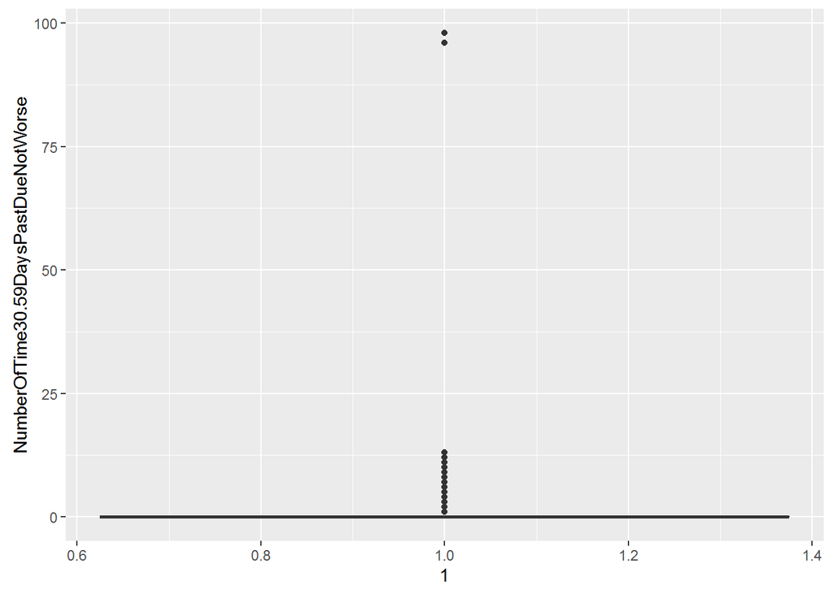

```r
ggplot(train_data, aes(y=NumberOfTime30.59DaysPastDueNotWorse, x = 1)) + geom_boxplot()
```

In this plot we can see the outliers.

> DebtRatio

Debt ratio is obtained by dividing Monthly debt payments, alimony, living costs by monthly gross income.

```r
str(train_data$DebtRatio)
```

```
##  num [1:150000] 0.803 0.1219 0.0851 0.036 0.0249 ...
```

```r
summary(train_data$DebtRatio)
```

```
##     Min.  1st Qu.   Median     Mean  3rd Qu.     Max.
##      0.0      0.2      0.4    353.0      0.9 329700.0
```

Usually debt ratio should be between 0 to 1. Somtimes it can exceed 1, if a person spends more than his income. Here its minimum is 0, mean is 353, median is 0.4. This indicates presence of outliers. Maximum value is 329700, which is not possible.

Exploring further by looking at percentile distribution

```r
quantile(train_data$DebtRatio,c(0.1,0.2,0.3,0.4,0.5,0.6,0.7,0.75,0.76,0.78,0.8,0.85,0.9,0.95,1))
```

```
##          10%          20%          30%          40%          50%
## 3.087398e-02 1.337729e-01 2.136969e-01 2.874603e-01 3.665078e-01
##          60%          70%          75%          76%          78%
## 4.675064e-01 6.491891e-01 8.682538e-01 9.511839e-01 1.275069e+00
##          80%          85%          90%          95%         100%
## 4.000000e+00 2.691500e+02 1.267000e+03 2.449000e+03 3.296640e+05
```

We can see upto 76 percentile DebtRatio is less than 1.

Visualizing the data with boxplot to have a better look.

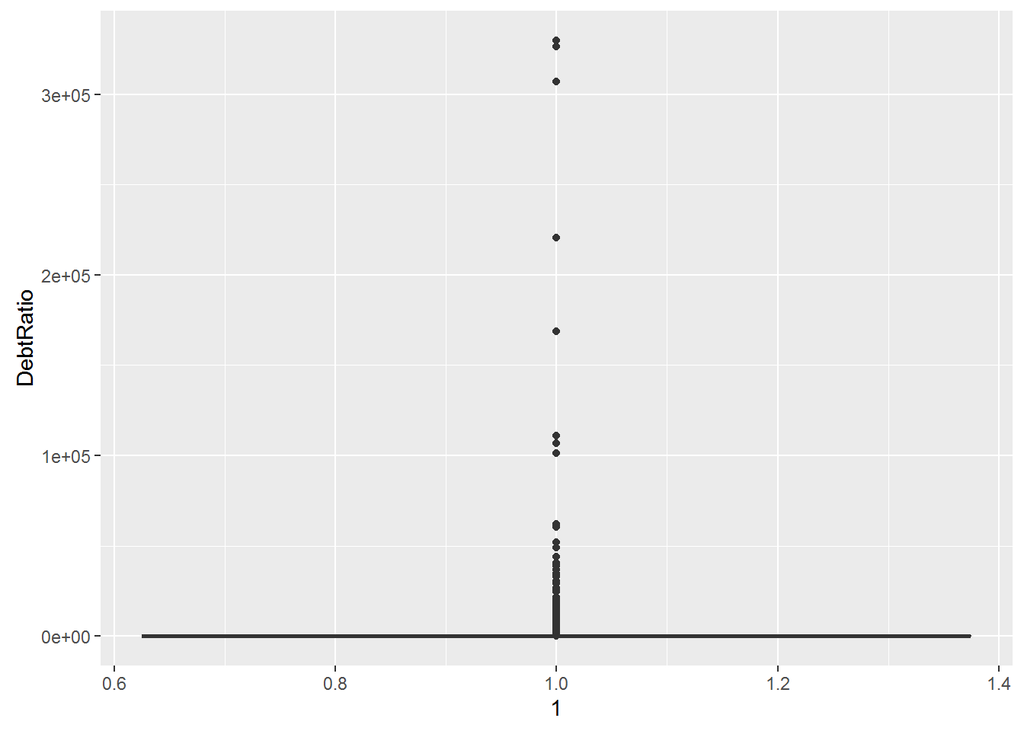

```r
ggplot(train_data, aes(y=DebtRatio, x = 1)) + geom_boxplot()
```

There are outlers present in the variable DebtRatio. We have to filter them before we use the data for model building.

> MonthlyIncome

This variable represents monthly income of the barrower.

```r
str(train_data$MonthlyIncome)
```

```
##  int [1:150000] 9120 2600 3042 3300 63588 3500 NA 3500 NA 23684 ...
```

```r
summary(train_data$MonthlyIncome)
```

```
##    Min. 1st Qu.  Median    Mean 3rd Qu.    Max.    NA's
##       0    3400    5400    6670    8249 3009000   29731
```

This is an integer variable and all the missing values represented by ‘NA’.  
Its minimum value is 0, which is practically impossible. Mean is 6670 and median is 5400 without considering NA values. Maximum value is 3009000.

We have to treat missing values first before going further into this variable analysis.

> NumberOfOpenCreditLinesAndLoans

This variable indicates number of open loans (an installment loan such as car loan or mortgage) and lines of credit (such as credit cards).

```r
str(train_data$NumberOfOpenCreditLinesAndLoans)
```

```
##  int [1:150000] 13 4 2 5 7 3 8 8 2 9 ...
```

```r
summary(train_data$NumberOfOpenCreditLinesAndLoans)
```

```
##    Min. 1st Qu.  Median    Mean 3rd Qu.    Max.
##   0.000   5.000   8.000   8.453  11.000  58.000
```

Lets see percentile distribution to know the outliers presence.

```r
quantile(train_data$NumberOfOpenCreditLinesAndLoans,c(0.1,0.2,0.3,0.4,0.5,0.6,0.7,0.8,0.9,0.93,0.95,0.97,0.98,0.99,0.995,1))
```

```
##   10%   20%   30%   40%   50%   60%   70%   80%   90%   93%   95%   97%
##     3     4     5     6     8     9    10    12    15    17    18    20
##   98%   99% 99.5%  100%
##    22    24    27    58
```

Highest value is 58 which seems normal.

Lets have a look on boxplot

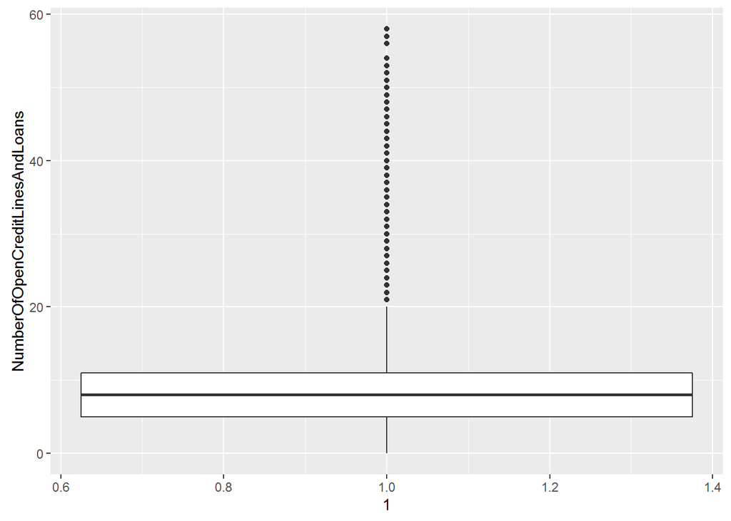

```r
ggplot(train_data, aes(y=NumberOfOpenCreditLinesAndLoans, x = 1)) + geom_boxplot()
```

> NumberOfTimes90DaysLate

This variable represents number of times borrower has been 90 days or more past due.

```r
str(train_data$NumberOfTimes90DaysLate)
```

```
##  int [1:150000] 0 0 1 0 0 0 0 0 0 0 ...
```

```r
summary(train_data$NumberOfTimes90DaysLate)
```

```
##    Min. 1st Qu.  Median    Mean 3rd Qu.    Max.
##   0.000   0.000   0.000   0.266   0.000  98.000
```

It is an integer variable. Minimum value is zero, median is also zero. Mean is 0.266 and maximum value is 98. These give indication of presence of outliers.

Check the percentile distribution to know the presence of outliers.

```r
quantile(train_data$NumberOfTimes90DaysLate,c(0,0.01,0.03,0.05,0.07,0.09,0.1,0.2,0.3,0.4,0.5,0.6,0.7,0.8,0.85,0.9,0.95,0.97,0.99,1))
```

```
##   0%   1%   3%   5%   7%   9%  10%  20%  30%  40%  50%  60%  70%  80%  85%
##    0    0    0    0    0    0    0    0    0    0    0    0    0    0    0
##  90%  95%  97%  99% 100%
##    0    1    1    3   98
```

100 percentile is 98, which is an outlier.

Variable ranges from 0 to 98. It takes only integers values. Lets see it’s frequency distribution.

```r
freq_table<-table(train_data$NumberOfTimes90DaysLate)
freq_table
```

```
##
##      0      1      2      3      4      5      6      7      8      9
## 141662   5243   1555    667    291    131     80     38     21     19
##     10     11     12     13     14     15     17     96     98
##      8      5      2      4      2      2      1      5    264
```

This variables has values from 0 to 15 and 17,96,98. Last two must be outliers.

Next, plot boxplot and barplots to visualize the data.

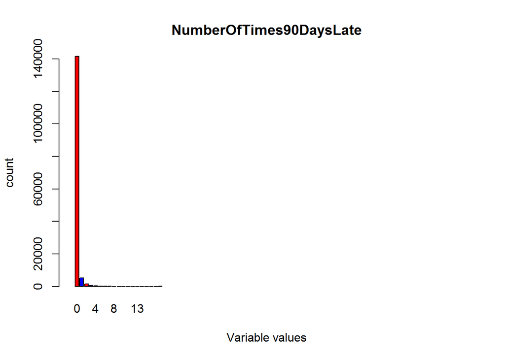

```r
barplot(freq_table,width=1,col = c("red","blue"),ylim = c(0, 140000),xlim=c(0,100),main="NumberOfTimes90DaysLate",xlab="Variable values",ylab="count")
```

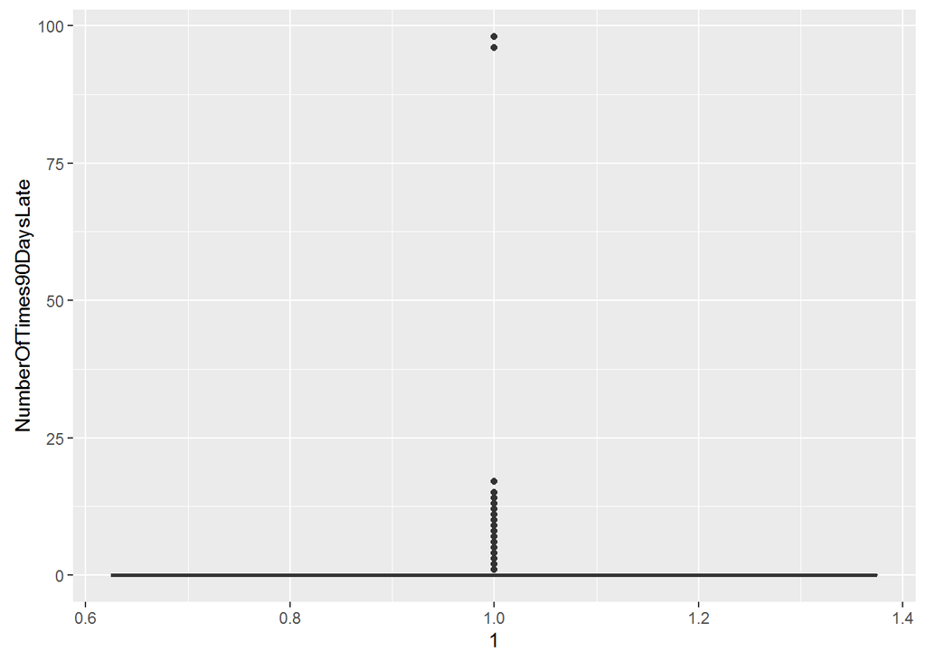

```r
ggplot(train_data, aes(y=NumberOfTimes90DaysLate, x = 1)) + geom_boxplot()
```

This plot also suggests presence of outliers.

> NumberRealEstateLoansOrLines

This variable shows number of mortgage and real estate loans taken by the barrower including home equity lines of credit.

```r
str(train_data$NumberRealEstateLoansOrLines)
```

```
##  int [1:150000] 6 0 0 0 1 1 3 0 0 4 ...
```

```r
summary(train_data$NumberRealEstateLoansOrLines)
```

```
##    Min. 1st Qu.  Median    Mean 3rd Qu.    Max.
##   0.000   0.000   1.000   1.018   2.000  54.000
```

It is an integer variable. Minimum value is zero, median is one. Mean is 1.018 and maximum value is 54. Mean and Median are close so, there may not be outliers in this variable.

Check the percentile distribution to know the presence of outliers.

```r
quantile(train_data$NumberRealEstateLoansOrLines,c(0,0.01,0.03,0.05,0.07,0.09,0.1,0.2,0.3,0.4,0.5,0.6,0.7,0.8,0.85,0.9,0.95,0.97,0.99,1))
```

```
##   0%   1%   3%   5%   7%   9%  10%  20%  30%  40%  50%  60%  70%  80%  85%
##    0    0    0    0    0    0    0    0    0    1    1    1    1    2    2
##  90%  95%  97%  99% 100%
##    2    3    3    4   54
```

100 percentile is at 54, which is a possible value for this variable.

This variable ranges from 0 to 54. It takes only integers values. Let’s see frequency distribution of this variable.

```r
freq_table<-table(train_data$NumberRealEstateLoansOrLines)
freq_table
```

```
##
##     0     1     2     3     4     5     6     7     8     9    10    11
## 56188 52338 31522  6300  2170   689   320   171    93    78    37    23
##    12    13    14    15    16    17    18    19    20    21    23    25
##    18    15     7     7     4     4     2     2     2     1     2     3
##    26    29    32    54
##     1     1     1     1
```

This variables has values from 0 to 21 and 23,25,26,29,32,54.

Plotting boxplot and barplots to visualize the data.

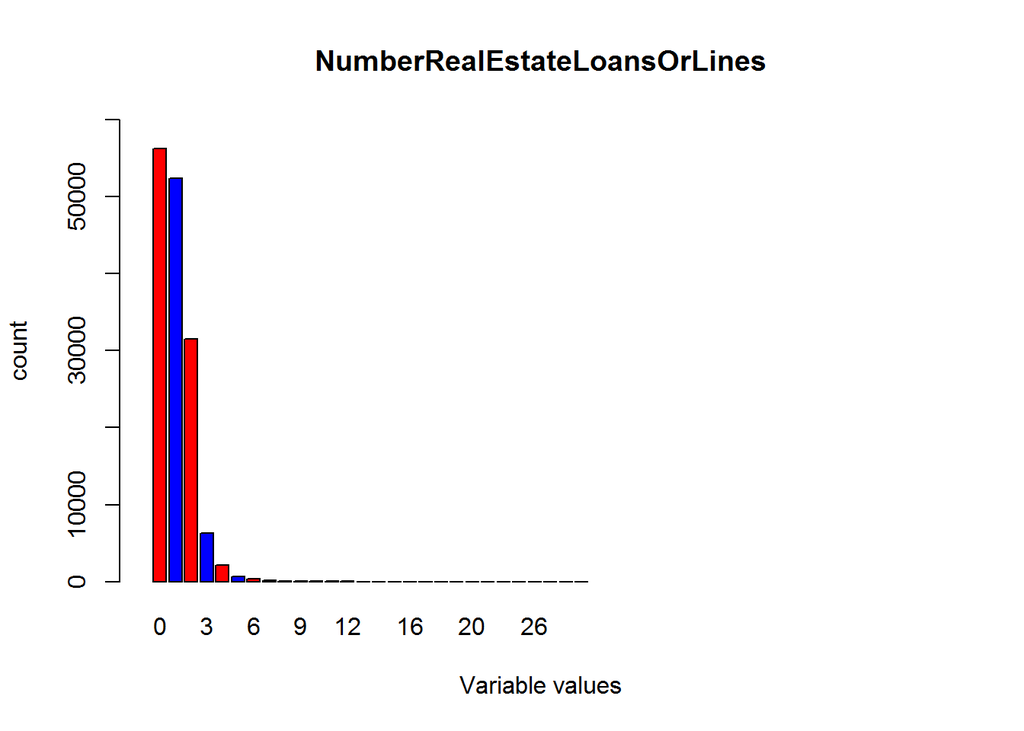

```r
barplot(freq_table,width=1,col = c("red","blue"),ylim = c(0, 60000),xlim=c(0,60),main="NumberRealEstateLoansOrLines",xlab="Variable values",ylab="count")
```

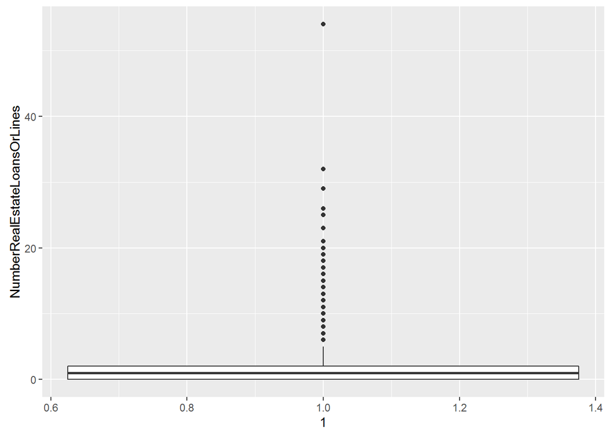

```r
ggplot(train_data, aes(y=NumberRealEstateLoansOrLines, x = 1)) + geom_boxplot()
```

> NumberOfTime60.89DaysPastDueNotWorse

It shows number of times borrower has been 60 to 89 days past due but no worse in the last 2 years.

```r
str(train_data$NumberOfTime60.89DaysPastDueNotWorse)
```

```
##  int [1:150000] 0 0 0 0 0 0 0 0 0 0 ...
```

```r
summary(train_data$NumberOfTime60.89DaysPastDueNotWorse)
```

```
##    Min. 1st Qu.  Median    Mean 3rd Qu.    Max.
##  0.0000  0.0000  0.0000  0.2404  0.0000 98.0000
```

It is an integer variable. Minimum value is zero, median is 0. Mean is 0.2404 and maximum value is 98. These give indication of presence of outliers.

Check the percentile distribution to know the presence of outliers.

```r
quantile(train_data$NumberOfTime60.89DaysPastDueNotWorse,c(0,0.01,0.03,0.05,0.07,0.09,0.1,0.2,0.3,0.4,0.5,0.6,0.7,0.8,0.85,0.9,0.95,0.97,0.99,1))
```

```
##   0%   1%   3%   5%   7%   9%  10%  20%  30%  40%  50%  60%  70%  80%  85%
##    0    0    0    0    0    0    0    0    0    0    0    0    0    0    0
##  90%  95%  97%  99% 100%
##    0    1    1    2   98
```

100 percentile is 98, which is an outlier.

This variable range is from 0 to 98.It takes only integers values. Lets see it’s frequency distribution.

```r
freq_table<-table(train_data$NumberOfTime60.89DaysPastDueNotWorse)
freq_table
```

```
##
##      0      1      2      3      4      5      6      7      8      9
## 142396   5731   1118    318    105     34     16      9      2      1
##     11     96     98
##      1      5    264
```

This variables has values from 0 to 9 and 11, 96, 98. Last two must be outliers.

Next plot boxplot and barplots to visualize the data.

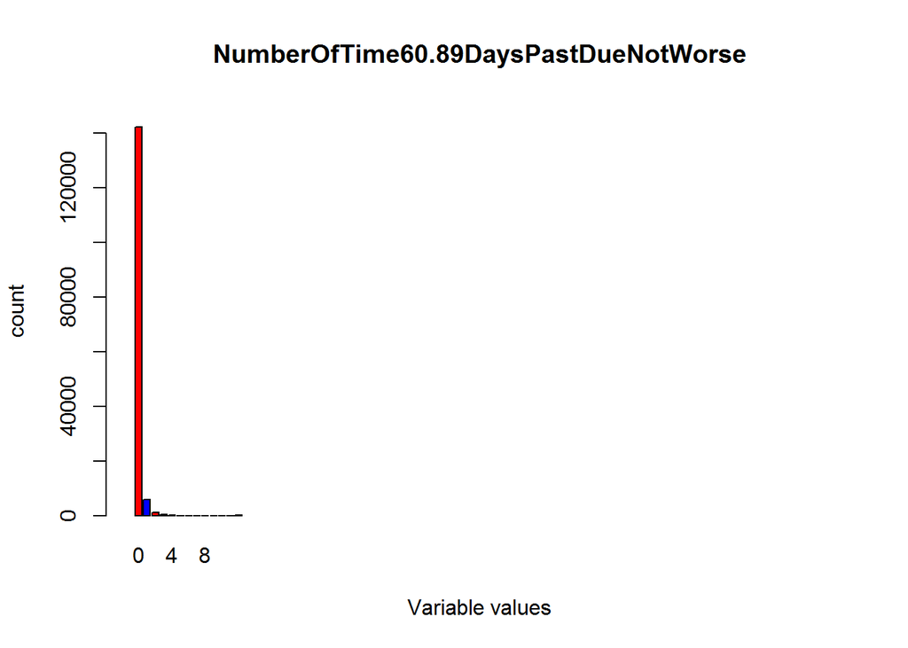

```r
barplot(freq_table,width=1,col = c("red","blue"),ylim = c(0, 150000),xlim=c(0,100),main="NumberOfTime60.89DaysPastDueNotWorse",xlab="Variable values",ylab="count")
```

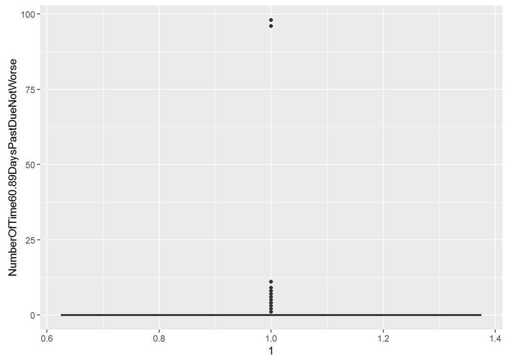

```r
ggplot(train_data, aes(y=NumberOfTime60.89DaysPastDueNotWorse, x = 1)) + geom_boxplot()
```

Boxplot clearly shows presence of outliers.

> NumberOfDependents

It represents number of dependents in the family of borrower excluding the borrower.

```r
str(train_data$NumberOfDependents)
```

```
##  int [1:150000] 2 1 0 0 0 1 0 0 NA 2 ...
```

```r
summary(train_data$NumberOfDependents)
```

```
##    Min. 1st Qu.  Median    Mean 3rd Qu.    Max.    NA's
##   0.000   0.000   0.000   0.757   1.000  20.000    3924
```

It is an integer variable. It has quite a lot missing values represented by ‘NA’.  
Its minimum value is 0. Mean is 0.757 and median is 0 without considering NA values. Maximum value is 20.

Lets tabularize what we found in univariate analysis

[output not shown]

Missing values need to be treated first before going further into this variable analysis.

We will build a model using uncleaned data and later clean the data.

## Model Building

Since the predictor variable (SeriousDlqin2yrs) is YES or NO type (Binary), logistic regression model seem to be a fair apporach.

The dataset contains training data set but no test data. We will divide our data set into two parts, first 125000 rows for training and remaining 25000 rows for testing.

First we build model without cleaning data, then we replace missing values, outliers with mean and build new model. We will check the accuracy of the model in both cases. If accuracy is increases after treating data then we will keep the model otherwise we will discard it. We do this for other models as well, we will take the model which gives better results.

### Logistic Regression

Splitting dataset into training and testing

```r
train_dataset<-train_data[1:125000,]
test_dataset<-train_data[125001:150000,]
```

Next we will build the model using train_dataset

```r
logmodel<- glm(SeriousDlqin2yrs ~ RevolvingUtilizationOfUnsecuredLines + age + NumberOfTime30.59DaysPastDueNotWorse + DebtRatio +   MonthlyIncome+NumberOfOpenCreditLinesAndLoans+NumberOfTimes90DaysLate+ NumberRealEstateLoansOrLines+ NumberOfTime60.89DaysPastDueNotWorse+NumberOfDependents, data = train_dataset, family = "binomial")
```

Using this model we will predict the output of test_dataset

```r
predicted_values<-ifelse(predict(logmodel,test_dataset)>0.5,1,0)
```

Our threshold (Decision Boundary) is taken 0.5. Any value greater than 0.5 is taken as 1, otherwise 0.

As we have predicted the values, we will use confusion matrix to calculate the accuracy of the model.

```r
conf_matrix<-table(test_dataset[,2],predicted_values)
conf_matrix
```

```
##    predicted_values
##         0     1
##   0 18576    27
##   1  1402    41
```

Here columns are predicted values, rows are actual values.

Accuracy is total true predictions divided by total predictions. We will also find sensitivity and specificity. Sensitivity is true positives/(true positives+false negatives) specificity is true negatives/(true negatives+false positivies)

```r
accuracy<-(conf_matrix[1,1]+conf_matrix[2,2])/sum(conf_matrix)
accuracy
```

```
## [1] 0.928714
```

```r
specificity<-conf_matrix[2,2]/(conf_matrix[2,2]+conf_matrix[2,1])
specificity
```

```
## [1] 0.02841303
```

```r
sensitivity<-conf_matrix[1,1]/(conf_matrix[1,1]+conf_matrix[1,2])
sensitivity
```

```
## [1] 0.9985486
```

Our model accuracy with uncleaned data is 0.928. Specificity is 0.028, which being quite low our model needs improvements.

In next step we will apply missing values treatment on the data, replacing the missing values with their means and will build new model.

#### Missing Values Treatment

MonthlyIncome and NumberOfDependents have missing values. After creating a new dataset we will replace missing values in above columns by their column mean values. **MonthlyIncome** In MonthlyIncome missing values are of 19.82%. We create a new column NA_MonthlyIncome which indicates whether the original value in MonthlyIncome was NA(TRUE) or not(FALSE).

```r
train_data1<-train_data
c1<-c(1:150000)[is.na(train_data[,7])]
train_data1[c1,7]<-6670
#We can get the mean of remaining observations in summary of that variable
train_data1$NA_MonthlyIncome<-is.na(train_data[,7])
```

**NumberOfDependents** In column NumberOfDependents missing values are of only 2.616%, we can just replace missing values by mean of remaining values without creating a new column

```r
c1<-c(1:150000)[is.na(train_data[,12])]
#We can get the mean of remaining observations in summary of that variable
train_data1[c1,12]<-0.757
```

Splitting new dataset train_data into training and testing datasets.

```r
train_dataset1<-train_data1[1:125000,]
test_dataset1<-train_data1[125001:150000,]
```

Next task is to build a new model, predicting values in testing daata and finding the accuracy.

```r
logmodel1 <- glm(SeriousDlqin2yrs ~ RevolvingUtilizationOfUnsecuredLines + age + NumberOfTime30.59DaysPastDueNotWorse + DebtRatio +   MonthlyIncome+NumberOfOpenCreditLinesAndLoans+NumberOfTimes90DaysLate+ NumberRealEstateLoansOrLines+ NumberOfTime60.89DaysPastDueNotWorse+NumberOfDependents+NA_MonthlyIncome, data = train_dataset1, family = "binomial")
predicted_values1<-ifelse(predict(logmodel1,test_dataset1)>0.5,1,0)
conf_matrix<-table(test_dataset1[,2],predicted_values1)
conf_matrix
```

```
##    predicted_values1
##         0     1
##   0 23234    34
##   1  1679    53
```

```r
accuracy<-(conf_matrix[1,1]+conf_matrix[2,2])/sum(conf_matrix)
accuracy
```

```
## [1] 0.93148
```

```r
specificity<-conf_matrix[2,2]/(conf_matrix[2,2]+conf_matrix[2,1])
specificity
```

```
## [1] 0.03060046
```

```r
sensitivity<-conf_matrix[1,1]/(conf_matrix[1,1]+conf_matrix[1,2])
sensitivity
```

```
## [1] 0.9985388
```

We can see model accuracy has been improved to 0.931after missing values treatment. But we still need some improvement in specificity.

In next step we will treat outliers.

#### Outliers Removal

We will create new dataset train_data2 using train_data1 in which we will replace the outliers with mean of that column.

```r
train_data2<-train_data1
```

**RevolvingUtilizationOfUnsecuredLines**

RevolvingUtilizationOfUnsecuredLines is a ratio, any value greater than 1 must be outlier. Since outliers percentage is less than 10, We will replace outliers with mean of remaining data.

```r
remain_mean<-mean(train_data1$RevolvingUtilizationOfUnsecuredLines[c(1:150000)[train_data1$RevolvingUtilizationOfUnsecuredLines<=1]])

train_data2[c(1:150000)[train_data1$RevolvingUtilizationOfUnsecuredLines>1],3]<-remain_mean
```

**age**

Only outlying value in variable ‘Age’ is zero, we replace it with mean of remaining values.

```r
remain_mean<-mean(train_data1$age[c(1:150000)[train_data1$age>0]])

train_data2[c(1:150000)[train_data1$age==0],4]<-remain_mean
```

**NumberOfTime30.59DaysPastDueNotWorse**

NumberOfTime30.59DaysPastDueNotWorse has values 96,98 as outliers which are of less than 10%. We can treat the outliers based on the related variable ‘SeriousDlqin2yrs’. ‘NumberOfTime30.59DaysPastDueNotWorse’ is directly related to ‘SeriousDlqin2yrs’. We create a frequency table between SeriousDlqin2yrs and NumberOfTime30.59DaysPastDueNotWorse.

```r
cross_table<-table(train_data1$NumberOfTime30.59DaysPastDueNotWorse,train_data1$SeriousDlqin2yrs)
cross_table
```

```
##
##           0      1
##   0  120977   5041
##   1   13624   2409
##   2    3379   1219
##   3    1136    618
##   4     429    318
##   5     188    154
##   6      66     74
##   7      26     28
##   8      17      8
##   9       8      4
##   10      1      3
##   11      0      1
##   12      1      1
##   13      0      1
##   96      1      4
##   98    121    143
```

For all the values in NumberOfTime30.59DaysPastDueNotWorse find the percentage of 0’s in SeriousDlqin2yrs. As both variables are related, We replace 96, 98 with the values whose 0’s percentage is same as former values.

```r
percent=0
for(i in 1:nrow(cross_table)){
  percent[i]=(cross_table[i,1]/(cross_table[i,1]+cross_table[i,2]))*100
}
percent
```

```
##  [1] 95.99978 84.97474 73.48847 64.76625 57.42972 54.97076 47.14286
##  [8] 48.14815 68.00000 66.66667 25.00000  0.00000 50.00000  0.00000
## [15] 20.00000 45.83333
```

We can see that for 98, 6 values have nearly same percent(45.83) and there are only 5 values of 96 in the variable. By this decuction we can replace both 98 and 96 with 6.

```r
train_data2[c(1:150000)[train_data1[,5]>13],5]<-6
```

**DebtRatio**

For DebtRatio we will take anything greater than 1 as outlier and replace them with remaining values mean. As outliers percentage is 23.4%, we crete a new row Outlier_DebtRatio to indicate whether that value is outlier and replaced or not.

```r
remain_mean<-mean(train_data1$DebtRatio[c(1:150000)[train_data1$DebtRatio<1]])
train_data2$Outlier_DebtRatio<-train_data1$DebtRatio>1
train_data2[c(1:150000)[train_data1$DebtRatio>1],6]<-remain_mean
```

**MonthlyIncome**

In MonthlyIncome we replaced missing values with mean. But first let’s check for outliers.

```r
summary(train_data1$MonthlyIncome)
```

```
##    Min. 1st Qu.  Median    Mean 3rd Qu.    Max.
##       0    3903    6600    6670    7400 3009000
```

```r
quantile(train_data1$MonthlyIncome,c(0,0.01,0.02,0.03,0.04,0.05,0.1,0.2,0.3,0.4,0.5,0.6,0.7,0.8,0.9,0.95,0.97,0.99,0.995,0.9975,1))
```

```
##         0%         1%         2%         3%         4%         5%
##       0.00       0.00     600.00    1000.00    1300.00    1500.00
##        10%        20%        30%        40%        50%        60%
##    2325.00    3400.00    4333.00    5400.00    6600.00    6670.00
##        70%        80%        90%        95%        97%        99%
##    6670.00    8250.00   10750.00   13500.00   16000.00   23000.00
##      99.5%     99.75%       100%
##   31250.00   44395.19 3008750.00
```

Observing the percentile distribution we will take upper limit as 50000 and lower limit as 1000. Anything out of this range will be considered as outlier. Let’s see total number of outliers.

```r
sum(train_data1$MonthlyIncome>50000)
```

```
## [1] 301
```

```r
sum(train_data1$MonthlyIncome<1000)
```

```
## [1] 4428
```

outliers are of 3.152%.

```r
median<-median(c(1:150000)[train_data1$MonthlyIncome<50000&train_data1$MonthlyIncome>1000])
median
```

```
## [1] 75010.5
```

```r
train_data2$MonthlyIncome[c(1:150000)[train_data1$MonthlyIncome<50000&train_data1$MonthlyIncome>1000]]<-median
```

**NumberOfTimes90DaysLate**

Outlier in NumberOfTimes90DaysLate can be treated same same as NumberOfTime30.59DaysPastDueNotWorse. Outliers are 96,98.

```r
cross_table<-table(train_data1$NumberOfTimes90DaysLate,train_data1$SeriousDlqin2yrs)
cross_table
```

```
##
##           0      1
##   0  135108   6554
##   1    3478   1765
##   2     779    776
##   3     282    385
##   4      96    195
##   5      48     83
##   6      32     48
##   7       7     31
##   8       6     15
##   9       5     14
##   10      3      5
##   11      2      3
##   12      1      1
##   13      2      2
##   14      1      1
##   15      2      0
##   17      0      1
##   96      1      4
##   98    121    143
```

```r
percent=0
for(i in 1:nrow(cross_table)){
  percent[i]=(cross_table[i,1]/(cross_table[i,1]+cross_table[i,2]))*100
}
percent
```

```
##  [1]  95.37349  66.33607  50.09646  42.27886  32.98969  36.64122  40.00000
##  [8]  18.42105  28.57143  26.31579  37.50000  40.00000  50.00000  50.00000
## [15]  50.00000 100.00000   0.00000  20.00000  45.83333
```

For values 98, 3 has close percentage. We replace both 96 and 98 with 3.

```r
train_data2[c(1:150000)[train_data1[,9]>17],9]<-3
```

**NumberOfTime60.89DaysPastDueNotWorse**

This variable again has 96, 98 as outliers and can be treated as NumberOfTime30.59DaysPastDueNotWorse.

```r
cross_table<-table(train_data1$NumberOfTime60.89DaysPastDueNotWorse,train_data1$SeriousDlqin2yrs)
cross_table
```

```
##
##           0      1
##   0  135140   7256
##   1    3954   1777
##   2     557    561
##   3     138    180
##   4      40     65
##   5      13     21
##   6       4     12
##   7       4      5
##   8       1      1
##   9       1      0
##   11      0      1
##   96      1      4
##   98    121    143
```

```r
percent=0
for(i in 1:nrow(cross_table)){
  percent[i]=(cross_table[i,1]/(cross_table[i,1]+cross_table[i,2]))*100
}
percent
```

```
##  [1]  94.90435  68.99319  49.82111  43.39623  38.09524  38.23529  25.00000
##  [8]  44.44444  50.00000 100.00000   0.00000  20.00000  45.83333
```

Values 98, 7 has close percentage. We will replace both 96 and 98 with 7.

```r
train_data2[c(1:150000)[train_data1[,11]>17],11]<-7
```

As all the outliers and missing values are cleaned, we can save and move further to create model with dataset ‘train_data2’.

```r
write.csv(train_data2,".../cleaned-data.csv")
```

### Model building after Data Cleaning

After Outlier Treatment, We can build a new model again using new data set. We divide data set for training and testing.

```r
train_dataset2<-train_data2[1:125000,]
test_dataset2<-train_data2[125001:150000,]
```

Createing the model, predecting the values on test data and finding accuracy:

```r
logmodel2 <- glm(SeriousDlqin2yrs ~ RevolvingUtilizationOfUnsecuredLines + age + NumberOfTime30.59DaysPastDueNotWorse + DebtRatio +   MonthlyIncome+NumberOfOpenCreditLinesAndLoans+NumberOfTimes90DaysLate+ NumberRealEstateLoansOrLines+ NumberOfTime60.89DaysPastDueNotWorse+NumberOfDependents+ NA_MonthlyIncome + Outlier_DebtRatio, data = train_dataset2, family = "binomial")

predicted_values<-ifelse(predict(logmodel2,test_dataset2)>0.5,1,0)
conf_matrix<-table(test_dataset2[,2],predicted_values)
conf_matrix
```

```
##    predicted_values
##         0     1
##   0 23163   105
##   1  1566   166
```

```r
accuracy<-(conf_matrix[1,1]+conf_matrix[2,2])/sum(conf_matrix)
accuracy
```

```
## [1] 0.93316
```

```r
specificity<-conf_matrix[2,2]/(conf_matrix[2,2]+conf_matrix[2,1])
specificity
```

```
## [1] 0.09584296
```

```r
sensitivity<-conf_matrix[1,1]/(conf_matrix[1,1]+conf_matrix[1,2])
sensitivity
```

```
## [1] 0.9954874
```

### Decision Tree

As specificity in the logistic regression model is not satisfactory, we can build a new model using decision trees. We need to install package ‘party’ for decision trees.

```r
library("party")
```

```r
dec_tree<-ctree(SeriousDlqin2yrs ~ RevolvingUtilizationOfUnsecuredLines + age + NumberOfTime30.59DaysPastDueNotWorse + DebtRatio +   MonthlyIncome+NumberOfOpenCreditLinesAndLoans+NumberOfTimes90DaysLate+ NumberRealEstateLoansOrLines+ NumberOfTime60.89DaysPastDueNotWorse+NumberOfDependents+ NA_MonthlyIncome + Outlier_DebtRatio, data = train_dataset2)
summary(dec_tree)
```

```
##     Length      Class       Mode
##          1 BinaryTree         S4
```

```r
predict_values<-predict(dec_tree, newdata=test_dataset2)
predicted_values<-ifelse(predict_values>0.5,1,0)
conf_matrix<-table(test_dataset2[,2],predicted_values)
conf_matrix
```

```
##    predicted_values
##         0     1
##   0 23085   183
##   1  1438   294
```

```r
accuracy<-(conf_matrix[1,1]+conf_matrix[2,2])/sum(conf_matrix)
accuracy
```

```
## [1] 0.93516
```

```r
specificity<-conf_matrix[2,2]/(conf_matrix[2,2]+conf_matrix[2,1])
specificity
```

```
## [1] 0.169746
```

```r
sensitivity<-conf_matrix[1,1]/(conf_matrix[1,1]+conf_matrix[1,2])
sensitivity
```

```
## [1] 0.9921351
```

**Accuracy paradox**

In our data there are way more number of positive cases(0) than negative cases(1).

```r
table(train_data[,2])
```

```
##
##      0      1
## 139974  10026
```

Ratio of zeros to ones is nearly 14:1 which indicates our data is imbalanced data. Imbalanced data typically refers to a problem with classification where the classes are not represented equally.

In our case models are giving more than 90% accuracy, but the accuracy is reflecting just the underlying class distribution. If we notice the confusion matrix, we can see that accuracy is mostly driven by ’0’s. Even though it is misclassifying most of the ’1’s we are getting high accuracy. This situation is called Accuracy Paradox.

One way to tackle the issue is using Averaging models imbalance and increase the specificity.

#### Averaging Models

The ratio of ones to zeros is 1:14. We divide data into two groups with ones and zeros.

```r
zeros_data<-train_data2[-c(1:150000)[train_data2[,2]==1],]
ones_data<-train_data2[-c(1:150000)[train_data2[,2]==0],]
```

Next we divide the zeros_data into 14 clusters using K-means clustering. Each time clustering changes when we run the code. So to get same clusters each time we write the line ‘set.seed(42)’ in the code.

```r
set.seed(42)
fit <- kmeans(zeros_data, 14)
zeros_clust<-data.frame(zeros_data, fit$cluster)
table(zeros_clust[,15])
```

```
##
##     1     2     3     4     5     6     7     8     9    10    11    12
##  9733  9725 15115  1469  1514 15188  9804 15130 13949 11901 15061 10074
##    13    14
##  9746  1565
```

zeros_clust has new column indicating cluster number. Above table shows number of elements in each cluster.

Next we build 14 models using each cluster and ones_data. ones_data will be used in all clusters , thus making most of the training sets a balanced ones in building models.

```r
models_list <- vector(mode="list", length=14)
for(j in 1:14){
  models_list[[j]]<-ctree(SeriousDlqin2yrs ~ RevolvingUtilizationOfUnsecuredLines + age + NumberOfTime30.59DaysPastDueNotWorse + DebtRatio +   MonthlyIncome+NumberOfOpenCreditLinesAndLoans+NumberOfTimes90DaysLate+ NumberRealEstateLoansOrLines+ NumberOfTime60.89DaysPastDueNotWorse+NumberOfDependents+ NA_MonthlyIncome + Outlier_DebtRatio, data = rbind(ones_data,zeros_data[c(1:nrow(zeros_clust))[zeros_clust[,15]==j],]))

}
```

Accuracy,specificity,sensitivity for all these models.

```r
specificity=0
accuracy=0
sensitivity=0
predict_values<-data.frame(matrix(0, ncol = 14, nrow = 150000))
for(j in 1:14){
predict_values[,j]<-predict(models_list[[j]], newdata=train_data2)
predicted_values<-ifelse(predict_values[,j]>0.5,1,0)
conf_matrix1<-table(train_data2[,2],predicted_values)

accuracy[j]<-(conf_matrix1[1,1]+conf_matrix1[2,2])/sum(conf_matrix1)
specificity[j]<-conf_matrix1[2,2]/(conf_matrix1[2,2]+conf_matrix1[2,1])
sensitivity[j]<-conf_matrix1[1,1]/(conf_matrix1[1,1]+conf_matrix1[1,2])

}
accuracy
```

```
##  [1] 0.7571667 0.7607400 0.8502800 0.0947400 0.0949000 0.8513067 0.7829267
##  [8] 0.8454733 0.8068267 0.7847400 0.8475600 0.7821267 0.7776200 0.0950200
```

```r
sensitivity
```

```
##  [1] 0.75431151 0.75855516 0.86400331 0.03087002 0.03110578 0.86520354
##  [7] 0.78372412 0.85819509 0.81168646 0.78580308 0.86078843 0.78298113
## [13] 0.77784446 0.03129867
```

```r
specificity
```

```
##  [1] 0.7970277 0.7912428 0.6586874 0.9864353 0.9855376 0.6572910 0.7717933
##  [8] 0.6678636 0.7389787 0.7698983 0.6628765 0.7701975 0.7744863 0.9846399
```

As accuracy or sensitivity is increasing to a model, its specificity is decreasing. We discard models 4,5,14 as their accuracies are very low. We take average of predicted probabilities of remaining models. We use this averaged probability to get output.

```r
predict_avg<-predict_values[,1]
for(j in c(1,2,3,6,7,8,9,10,11,12,13)){
     predict_avg<-predict_avg+predict_values[,j]
      }
predict_avg<-predict_avg/11
predicted_values<-ifelse(predict_avg>0.5,1,0)

conf_matrix<-table(train_data2[,2],predicted_values)
accuracy_avg<-(conf_matrix[1,1]+conf_matrix[2,2])/sum(conf_matrix)
accuracy_avg
```

```
## [1] 0.78316
```

```r
specificity_avg<-conf_matrix[2,2]/(conf_matrix[2,2]+conf_matrix[2,1])
specificity_avg
```

```
## [1] 0.778077
```

```r
sensitivity_avg<-conf_matrix[1,1]/(conf_matrix[1,1]+conf_matrix[1,2])
sensitivity_avg
```

```
## [1] 0.7835241
```

Specificity of the averaged model is 0.778 and accuracy is 0.783 which are good values. We can still increase the specificity by decreasing the threshold, but by doing so accuracy and sensitivity might decreas.

Let’s check specificity,accuracy for a decreased threshold value of 0.4.

```r
predicted_values<-ifelse(predict_avg>0.4,1,0)

conf_matrix<-table(train_data2[,2],predicted_values)
accuracy_avg<-(conf_matrix[1,1]+conf_matrix[2,2])/sum(conf_matrix)
accuracy_avg
```

```
## [1] 0.71504
```

```r
specificity_avg<-conf_matrix[2,2]/(conf_matrix[2,2]+conf_matrix[2,1])
specificity_avg
```

```
## [1] 0.8401157
```

```r
sensitivity_avg<-conf_matrix[1,1]/(conf_matrix[1,1]+conf_matrix[1,2])
sensitivity_avg
```

```
## [1] 0.7060811
```

We can see Specificity has increased to 0.84 and but Accuracy of our Averaging model has decreased to 0.71.